# Exercise 6 Solutions

1. This question uses the !Kung height vs. weight data from the Rethinking package for adults age 18 or older.
1. Load, filter the data (age>=18) and plot the data.

```r
library(rethinking)
data(Howell1)
d <- Howell1
d2 <- d[ d$age >= 18 , ]
head(d2)
```

```
##    height   weight age male
## 1 151.765 47.82561  63    1
## 2 139.700 36.48581  63    0
## 3 136.525 31.86484  65    0
## 4 156.845 53.04191  41    1
## 5 145.415 41.27687  51    0
## 6 163.830 62.99259  35    1
```

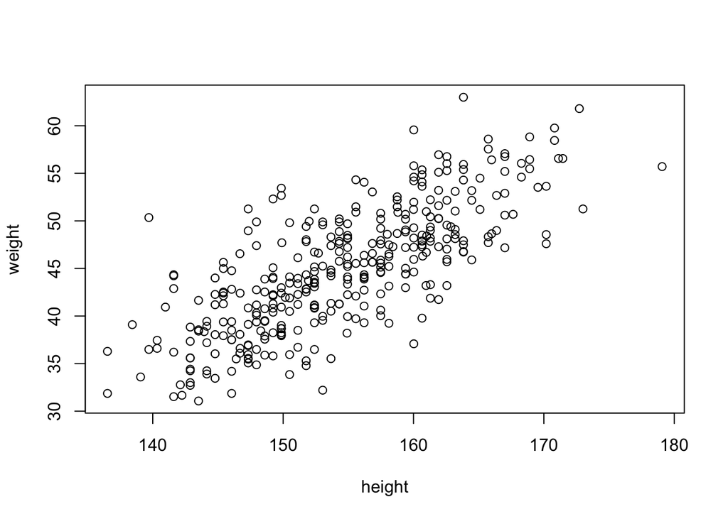

```r
plot(weight~height, data=d2)
```

2. Fit a linear regression to these data using the ‘lm’ command within R. The model should predict the observed weight from height and so the model should include an intercept and an effect of height.

```r
myLM<-lm(weight~height,data=d2)
summary(myLM)
```

```
##
## Call:
## lm(formula = weight ~ height, data = d2)
##
## Residuals:
##      Min       1Q   Median       3Q      Max
## -11.8022  -3.0183  -0.2293   2.8117  14.7348
##
## Coefficients:
##              Estimate Std. Error t value Pr(>|t|)
## (Intercept) -52.31618    4.52650  -11.56   <2e-16 ***
## height        0.62942    0.02924   21.52   <2e-16 ***
## ---
## Signif. codes:  0 '***' 0.001 '**' 0.01 '*' 0.05 '.' 0.1 ' ' 1
##
## Residual standard error: 4.242 on 350 degrees of freedom
## Multiple R-squared:  0.5696, Adjusted R-squared:  0.5684
## F-statistic: 463.3 on 1 and 350 DF,  p-value: < 2.2e-16
```

So the estimate of the intercept is -52.32, and effect of height on weight is 0.63. I was unclear in my instructions so its fine if you estimated the effect of weight on height. The estimate of SD is given by the residual standard error and so is 4.24.

3. Plot the estimated linear fit superimposed on the data and report the parameter estimates for the intercept, effect of height, and sigma.

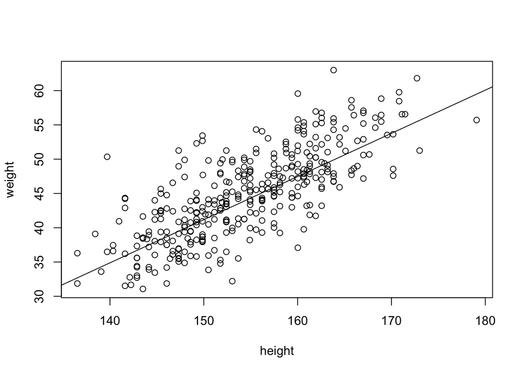

```r
plot(weight~height, data=d2)
abline(a=-53.32,b=0.63)
```

2. Repeat 1 using the Rethinking package’s quap function.

```r
library(rethinking)
lm.qa <- quap(
    alist(
        weight ~ dnorm(mu,sd) ,  # normal likelihood
        sd ~ dexp(1),     # exponential prior
        mu<-intercept + beta*height,
        intercept~dnorm(0,10),
        beta~dnorm(0,10)
    ) ,
    data=list(weight=d2$weight,height=d2$height) )

precis(lm.qa)
```

```
##                  mean         sd        5.5%       94.5%
## sd          4.2276112 0.15935784   3.9729266   4.4822958
## intercept -43.4768298 4.14939580 -50.1083657 -36.8452939
## beta        0.5723875 0.02681265   0.5295357   0.6152393
```

3. Repeat 1) except fitting your model using your own likelihood function rather than R’s built in ‘lm’. Plot the estimated linear fit superimposed on the data and report the parameter estimates for the intercept, effect of height, and sigma. Are they the same as from ‘lm’? Hints: We need a function that accepts a vector of the model parameters and returns a negative log likelihood. We then use Optim to minimize the negative log likelihood, which is equivalent to maximzing the likelihood.

```r
nllNormReg<-function(parVec,data=d2){
  wt<-data$weight
  ht<-data$height
  intercept<-parVec[1]
  beta<-parVec[2]
  mySd<-parVec[3]
  wtPred<-intercept+beta*ht
  nllik<- -sum(dnorm(x=wt,mean=wtPred,sd=mySd,log=TRUE))
  return(nllik)
}

parVec<-c(1.0,10.0,5.0) # Need some starting parameters for gradient climbing/descending methods
outLM<-optim(par=parVec,fn=nllNormReg,method="L-BFGS-B",
               lower=c(-Inf,-Inf,0.0001),upper=c(Inf,Inf,Inf))
outLM$par #
```

```
## [1] -52.316787   0.629425   4.229643
```

The estimates are very similiar to those from R’s built in lm(). Note that lm() uses OLS (ordinary least squares) rather than maximum likelihood.

4. Multivariate regression. Add the effect of sex as an indicator (or index) variable to the regression of height vs weight for the !Kung data. Fit this multivariate regression using the first three methods (i.e., lm(), likelihood function, and quap) presented in the R notebook that will be available here.